# Machine Learning I. Trabajo de evaluación. Temas: Análisis Discriminante, Naïve Bayes, SVM

Jerónimo Carranza Carranza

15 de junio de 2017

# 1 Naïve Bayes

Sobre la base de datos *BreastCancer* de la librería *mlbench*, realice las siguientes actividades:

1. Construya un clasificador Naive-Bayes usando una muestra aleatoria constituida por 2/3 de la totalidad del fichero de datos.
2. Obtenga la matriz de confusión y el porcentaje de clasificación incorrecta a partir de las instancias no usadas en la construcción del clasificador.
3. Determine el número de predicciones correspondientes a la clase malignant.
4. De las predicciones consideradas en el apartado anterior, determine cuántas de ellas se han obtenido con una probabilidad mayor que 0.75

## 1.1 Lectura de datos

```r
library(mlbench)
data(BreastCancer)

str(BreastCancer)
```

```
## 'data.frame':    699 obs. of  11 variables:
##  $ Id             : chr  "1000025" "1002945" "1015425" "1016277" ...
##  $ Cl.thickness   : Ord.factor w/ 10 levels "1"<"2"<"3"<"4"<..: 5 5 3 6 4 8 1 2 2 4 ...
##  $ Cell.size      : Ord.factor w/ 10 levels "1"<"2"<"3"<"4"<..: 1 4 1 8 1 10 1 1 1 2 ...
##  $ Cell.shape     : Ord.factor w/ 10 levels "1"<"2"<"3"<"4"<..: 1 4 1 8 1 10 1 2 1 1 ...
##  $ Marg.adhesion  : Ord.factor w/ 10 levels "1"<"2"<"3"<"4"<..: 1 5 1 1 3 8 1 1 1 1 ...
##  $ Epith.c.size   : Ord.factor w/ 10 levels "1"<"2"<"3"<"4"<..: 2 7 2 3 2 7 2 2 2 2 ...
##  $ Bare.nuclei    : Factor w/ 10 levels "1","2","3","4",..: 1 10 2 4 1 10 10 1 1 1 ...
##  $ Bl.cromatin    : Factor w/ 10 levels "1","2","3","4",..: 3 3 3 3 3 9 3 3 1 2 ...
##  $ Normal.nucleoli: Factor w/ 10 levels "1","2","3","4",..: 1 2 1 7 1 7 1 1 1 1 ...
##  $ Mitoses        : Factor w/ 9 levels "1","2","3","4",..: 1 1 1 1 1 1 1 1 5 1 ...
##  $ Class          : Factor w/ 2 levels "benign","malignant": 1 1 1 1 1 2 1 1 1 1 ...
```

```r
head(BreastCancer)
```

```
##        Id Cl.thickness Cell.size Cell.shape Marg.adhesion Epith.c.size
## 1 1000025            5         1          1             1            2
## 2 1002945            5         4          4             5            7
## 3 1015425            3         1          1             1            2
## 4 1016277            6         8          8             1            3
## 5 1017023            4         1          1             3            2
## 6 1017122            8        10         10             8            7
##   Bare.nuclei Bl.cromatin Normal.nucleoli Mitoses     Class
## 1           1           3               1       1    benign
## 2          10           3               2       1    benign
## 3           2           3               1       1    benign
## 4           4           3               7       1    benign
## 5           1           3               1       1    benign
## 6          10           9               7       1 malignant
```

Conjunto con 699 casos y 11 variables, de las cuales una, *Id*, es de tipo texto, cinco son factores ordenados y otros cinco nominales, el último de los cuales, *Class*, dicotómico, es la variable objetivo, que identifica la clase de tumor; benigno o maligno.

## 1.2 Resumen de datos

```r
summary(BreastCancer)
```

```
##       Id             Cl.thickness   Cell.size     Cell.shape
##  Length:699         1      :145   1      :384   1      :353
##  Class :character   5      :130   10     : 67   2      : 59
##  Mode  :character   3      :108   3      : 52   10     : 58
##                     4      : 80   2      : 45   3      : 56
##                     10     : 69   4      : 40   4      : 44
##                     2      : 50   5      : 30   5      : 34
##                     (Other):117   (Other): 81   (Other): 95
##  Marg.adhesion  Epith.c.size  Bare.nuclei   Bl.cromatin  Normal.nucleoli
##  1      :407   2      :386   1      :402   2      :166   1      :443
##  2      : 58   3      : 72   10     :132   3      :165   10     : 61
##  3      : 58   4      : 48   2      : 30   1      :152   3      : 44
##  10     : 55   1      : 47   5      : 30   7      : 73   2      : 36
##  4      : 33   6      : 41   3      : 28   4      : 40   8      : 24
##  8      : 25   5      : 39   (Other): 61   5      : 34   6      : 22
##  (Other): 63   (Other): 66   NA's   : 16   (Other): 69   (Other): 69
##     Mitoses          Class
##  1      :579   benign   :458
##  2      : 35   malignant:241
##  3      : 33
##  10     : 14
##  4      : 12
##  7      :  9
##  (Other): 17
```

Aparecen 16 casos perdidos para la variable *Bare.nuclei*.

La variable objetivo manifiesta cierto desbalanceamiento, con aproximadamente el doble de casos ‘benignos’ frente a los ‘malignos’.

## 1.3 Conjuntos de entrenamiento y test

```r
set.seed(12345)
n = nrow(BreastCancer)
ind = sample(n, n*2/3)

BCtrain = BreastCancer[ind,]
BCtest = BreastCancer[-ind,]
```

## 1.4 Clasificador Naïve-Bayes

No se incluyen en x (predictores) los identificadores de caso (Id) ni logicamente la variable objetivo (Class).

```r
library(e1071)
modelNB = naiveBayes(x=subset(BCtrain, select=c(-Id,-Class)),
                     y=BCtrain$Class)
modelNB
```

```
##
## Naive Bayes Classifier for Discrete Predictors
##
## Call:
## naiveBayes.default(x = subset(BCtrain, select = c(-Id, -Class)),
##     y = BCtrain$Class)
##
## A-priori probabilities:
## BCtrain$Class
##    benign malignant
## 0.6437768 0.3562232
##
## Conditional probabilities:
##              Cl.thickness
## BCtrain$Class           1           2           3           4           5
##     benign    0.296666667 0.103333333 0.216666667 0.136666667 0.186666667
##     malignant 0.018072289 0.012048193 0.054216867 0.036144578 0.198795181
##              Cl.thickness
## BCtrain$Class           6           7           8           9          10
##     benign    0.050000000 0.003333333 0.006666667 0.000000000 0.000000000
##     malignant 0.072289157 0.090361446 0.204819277 0.042168675 0.271084337
##
##              Cell.size
## BCtrain$Class           1           2           3           4           5
##     benign    0.833333333 0.083333333 0.053333333 0.020000000 0.000000000
##     malignant 0.012048193 0.042168675 0.108433735 0.114457831 0.126506024
##              Cell.size
## BCtrain$Class           6           7           8           9          10
##     benign    0.003333333 0.000000000 0.003333333 0.003333333 0.000000000
##     malignant 0.114457831 0.060240964 0.102409639 0.024096386 0.295180723
##
##              Cell.shape
## BCtrain$Class           1           2           3           4           5
##     benign    0.793333333 0.103333333 0.066666667 0.020000000 0.003333333
##     malignant 0.006024096 0.012048193 0.108433735 0.132530120 0.144578313
##              Cell.shape
## BCtrain$Class           6           7           8           9          10
##     benign    0.006666667 0.003333333 0.003333333 0.000000000 0.000000000
##     malignant 0.102409639 0.114457831 0.096385542 0.042168675 0.240963855
##
```

[output cut: 38 more lines]

```
##     benign    0.880000000 0.073333333 0.016666667 0.000000000 0.006666667
##     malignant 0.156626506 0.018072289 0.132530120 0.060240964 0.084337349
##              Normal.nucleoli
## BCtrain$Class           6           7           8           9          10
##     benign    0.010000000 0.003333333 0.010000000 0.000000000 0.000000000
##     malignant 0.066265060 0.048192771 0.084337349 0.066265060 0.283132530
##
##              Mitoses
## BCtrain$Class           1           2           3           4           5
##     benign    0.983333333 0.013333333 0.003333333 0.000000000 0.000000000
##     malignant 0.584337349 0.084337349 0.120481928 0.048192771 0.018072289
##              Mitoses
## BCtrain$Class           6           7           8          10
##     benign    0.000000000 0.000000000 0.000000000 0.000000000
##     malignant 0.018072289 0.030120482 0.036144578 0.060240964
```

## 1.5 Predicciones

```r
predNB = predict(object=modelNB,newdata=BCtest)
predNB
```

```
##   [1] benign    benign    benign    benign    benign    malignant malignant
##   [8] malignant benign    benign    benign    malignant malignant malignant
##  [15] malignant malignant benign    malignant malignant malignant benign
##  [22] malignant malignant benign    malignant benign    benign    benign
##  [29] benign    benign    malignant benign    benign    benign    benign
##  [36] benign    benign    malignant benign    benign    malignant benign
##  [43] benign    malignant malignant benign    benign    benign    benign
##  [50] malignant benign    benign    benign    benign    benign    benign
##  [57] malignant benign    benign    benign    benign    malignant malignant
##  [64] benign    benign    malignant benign    benign    malignant malignant
##  [71] benign    benign    benign    benign    malignant malignant malignant
##  [78] malignant malignant malignant benign    malignant malignant benign
##  [85] benign    benign    benign    malignant malignant malignant benign
##  [92] malignant malignant malignant malignant benign    benign    malignant
##  [99] benign    benign    benign    benign    malignant malignant benign
```

[output cut: 20 more lines]

## 1.6 Matriz de confusión

```r
matconf = table(predNB,BCtest$Class,dnn=c("Predicha","Real"))
matconf
```

```
##            Real
## Predicha    benign malignant
##   benign       153         1
##   malignant      5        74
```

## 1.7 Porcentaje de clasificación incorrecta

```r
100*(1-(sum(diag(matconf))/nrow(BCtest)))
```

```
## [1] 2.575107
```

## 1.8 Número de predicciones de la clase *malignant*

```r
matconf[2,]
```

```
##    benign malignant
##         5        74
```

```r
sum(matconf[2,])
```

```
## [1] 79
```

## 1.9 Predicciones *malignant* con p > 0.75

```r
predNBp = as.data.frame(
  predict(object = modelNB, newdata = BCtest, type = 'raw'))

malP75 = predNBp[predNBp$malignant>0.75,]
malP75
```

```
##           benign malignant
## 6   7.152782e-11 1.0000000
## 7   6.942402e-11 1.0000000
## 8   1.301153e-01 0.8698847
## 12  1.338615e-12 1.0000000
## 13  5.332730e-05 0.9999467
## 14  9.168903e-07 0.9999991
## 15  2.454265e-12 1.0000000
## 16  2.403509e-04 0.9997596
## 18  4.075326e-09 1.0000000
## 19  1.129415e-03 0.9988706
## 20  3.448966e-10 1.0000000
## 22  5.195326e-06 0.9999948
## 23  1.795341e-06 0.9999982
## 25  3.016044e-10 1.0000000
```

[output cut: 65 more lines]

```r
cat('\n Número de predicciones malignant con p > 0.75: \t',nrow(malP75), '\n',
'Porcentaje de predicciones malignant con p > 0.75: \t',100*nrow(malP75)/sum(matconf[2,]),'%')
```

```
##
##  Número de predicciones malignant con p > 0.75:   79
##  Porcentaje de predicciones malignant con p > 0.75:   100 %
```

# 2 SVM

| RI | Na | Mg | Al | Si | K | Ca | Ba | Fe |
| --- | --- | --- | --- | --- | --- | --- | --- | --- |
| 1.49 | 13.45 | 4.05 | 1.21 | 73.18 | 0.37 | 7.98 | 0.2 | 0 |
| 1.52 | 13.74 | 3.87 | 1.29 | 71.97 | 0.25 | 8.02 | 0 | 0.13 |

## 2.1 Lectura de datos

```r
library(mlbench)
data(Glass)

str(Glass)
```

```
## 'data.frame':    214 obs. of  10 variables:
##  $ RI  : num  1.52 1.52 1.52 1.52 1.52 ...
##  $ Na  : num  13.6 13.9 13.5 13.2 13.3 ...
##  $ Mg  : num  4.49 3.6 3.55 3.69 3.62 3.61 3.6 3.61 3.58 3.6 ...
##  $ Al  : num  1.1 1.36 1.54 1.29 1.24 1.62 1.14 1.05 1.37 1.36 ...
##  $ Si  : num  71.8 72.7 73 72.6 73.1 ...
##  $ K   : num  0.06 0.48 0.39 0.57 0.55 0.64 0.58 0.57 0.56 0.57 ...
##  $ Ca  : num  8.75 7.83 7.78 8.22 8.07 8.07 8.17 8.24 8.3 8.4 ...
##  $ Ba  : num  0 0 0 0 0 0 0 0 0 0 ...
##  $ Fe  : num  0 0 0 0 0 0.26 0 0 0 0.11 ...
##  $ Type: Factor w/ 6 levels "1","2","3","5",..: 1 1 1 1 1 1 1 1 1 1 ...
```

```r
head(Glass)
```

```
##        RI    Na   Mg   Al    Si    K   Ca Ba   Fe Type
## 1 1.52101 13.64 4.49 1.10 71.78 0.06 8.75  0 0.00    1
## 2 1.51761 13.89 3.60 1.36 72.73 0.48 7.83  0 0.00    1
## 3 1.51618 13.53 3.55 1.54 72.99 0.39 7.78  0 0.00    1
## 4 1.51766 13.21 3.69 1.29 72.61 0.57 8.22  0 0.00    1
## 5 1.51742 13.27 3.62 1.24 73.08 0.55 8.07  0 0.00    1
## 6 1.51596 12.79 3.61 1.62 72.97 0.64 8.07  0 0.26    1
```

Conjunto con 214 casos y 10 variables, todas ellas de tipo numérico, salvo la última, *Type*, que es un factor con seis niveles y es la variable objetivo.

## 2.2 Resumen de datos

```r
summary(Glass)
```

```
##        RI              Na              Mg              Al
##  Min.   :1.511   Min.   :10.73   Min.   :0.000   Min.   :0.290
##  1st Qu.:1.517   1st Qu.:12.91   1st Qu.:2.115   1st Qu.:1.190
##  Median :1.518   Median :13.30   Median :3.480   Median :1.360
##  Mean   :1.518   Mean   :13.41   Mean   :2.685   Mean   :1.445
##  3rd Qu.:1.519   3rd Qu.:13.82   3rd Qu.:3.600   3rd Qu.:1.630
##  Max.   :1.534   Max.   :17.38   Max.   :4.490   Max.   :3.500
##        Si              K                Ca               Ba
##  Min.   :69.81   Min.   :0.0000   Min.   : 5.430   Min.   :0.000
##  1st Qu.:72.28   1st Qu.:0.1225   1st Qu.: 8.240   1st Qu.:0.000
##  Median :72.79   Median :0.5550   Median : 8.600   Median :0.000
##  Mean   :72.65   Mean   :0.4971   Mean   : 8.957   Mean   :0.175
##  3rd Qu.:73.09   3rd Qu.:0.6100   3rd Qu.: 9.172   3rd Qu.:0.000
##  Max.   :75.41   Max.   :6.2100   Max.   :16.190   Max.   :3.150
##        Fe          Type
##  Min.   :0.00000   1:70
##  1st Qu.:0.00000   2:76
##  Median :0.00000   3:17
##  Mean   :0.05701   5:13
##  3rd Qu.:0.10000   6: 9
##  Max.   :0.51000   7:29
```

## 2.3 Clasificador SVM1

```r
library(e1071)
```

```r
svm1 = svm(Type ~ ., data=Glass, kernel = 'radial', cost = 0.8, gamma = 0.5, cross = 10)
```

```r
summary(svm1)
```

```
##
## Call:
## svm(formula = Type ~ ., data = Glass, kernel = "radial", cost = 0.8,
##     gamma = 0.5, cross = 10)
##
##
## Parameters:
##    SVM-Type:  C-classification
##  SVM-Kernel:  radial
##        cost:  0.8
##       gamma:  0.5
##
## Number of Support Vectors:  183
##
##  ( 58 64 17 13 9 22 )
##
##
## Number of Classes:  6
##
## Levels:
##  1 2 3 5 6 7
##
## 10-fold cross-validation on training data:
##
## Total Accuracy: 66.35514
## Single Accuracies:
##  57.14286 57.14286 72.72727 52.38095 59.09091 71.42857 71.42857 68.18182 76.19048 77.27273
```

La función *summary* proporciona los resultados básicos del modelo, y en particular la tasa de clasificación correcta global (66.36%) y en cada pliegue, en este caso oscilando entre 52.38% y 77.27%.

## 2.4 Ajuste de parámetros

```r
(svm1t = tune.svm(Type ~ ., data=Glass, kernel = 'radial',
           cost = c(2^(-5),2^(-3),2^(-1),2,2^3,2^5),
           gamma = c(2^(-7),2^(-5),2^(-3),2^(-1),2,2^3), cross = 10))
```

```
##
## Parameter tuning of 'svm':
##
## - sampling method: 10-fold cross validation
##
## - best parameters:
##    gamma cost
##  0.03125    8
##
## - best performance: 0.30671
```

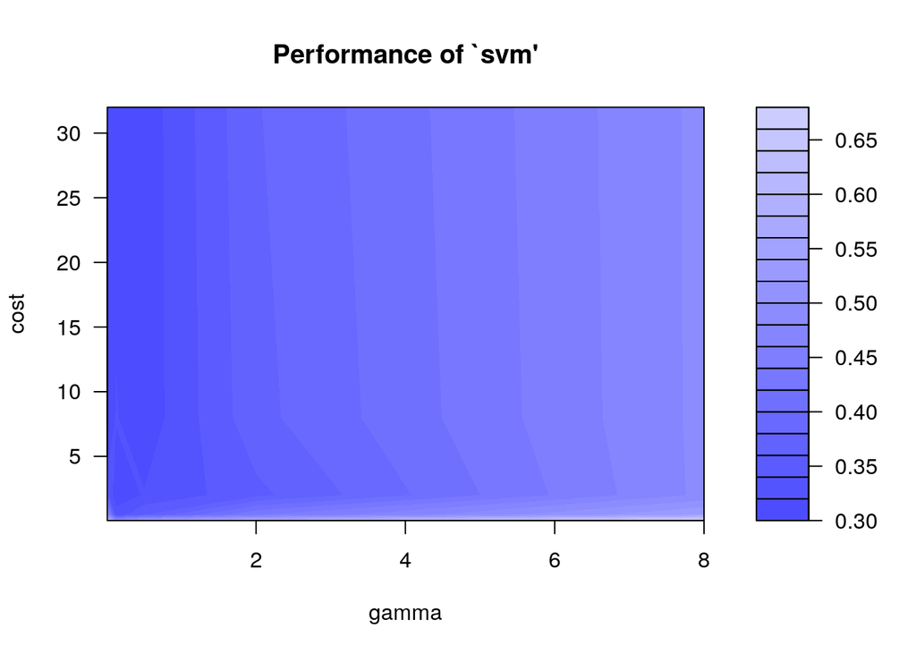

```r
plot(svm1t)
```

## 2.5 Predicciones con mejor modelo

```r
(svm1tb = svm1t$best.model)
```

```
##
## Call:
## best.svm(x = Type ~ ., data = Glass, gamma = c(2^(-7), 2^(-5),
##     2^(-3), 2^(-1), 2, 2^3), cost = c(2^(-5), 2^(-3), 2^(-1),
##     2, 2^3, 2^5), kernel = "radial", cross = 10)
##
##
## Parameters:
##    SVM-Type:  C-classification
##  SVM-Kernel:  radial
##        cost:  8
##       gamma:  0.03125
##
## Number of Support Vectors:  157
```

```r
(test = data.frame('RI'=c(1.49,1.52),'Na'=c(13.45,13.74),'Mg'=c(4.05,3.87),'Al'=c(1.21,1.29),'Si'=c(73.18,71.97),'K'=c(0.37,0.25),'Ca'=c(7.98,8.02), 'Ba'=c(0.2,0),'Fe'=c(0,0.13)))
```

```
##     RI    Na   Mg   Al    Si    K   Ca  Ba   Fe
## 1 1.49 13.45 4.05 1.21 73.18 0.37 7.98 0.2 0.00
## 2 1.52 13.74 3.87 1.29 71.97 0.25 8.02 0.0 0.13
```

```r
(predict(svm1tb,test))
```

```
## 1 2
## 7 2
## Levels: 1 2 3 5 6 7
```

Las dos instancias son clasificadas en los tipos 7 y 2.

## 2.6 Reajuste con validación cruzada de 15 pliegues

```r
(tc = tune.control(cross = 15))
```

[output not shown]

```r
(svm1t = tune.svm(Type ~ ., data=Glass, kernel = 'radial',
           cost = c(2^(-5),2^(-3),2^(-1),2,2^3,2^5),
           gamma = c(2^(-7),2^(-5),2^(-3),2^(-1),2,2^3),
           tunecontrol =tc))
```

```
##
## Parameter tuning of 'svm':
##
## - sampling method: 15-fold cross validation
##
## - best parameters:
##    gamma cost
##  0.03125    8
##
## - best performance: 0.2755556
```

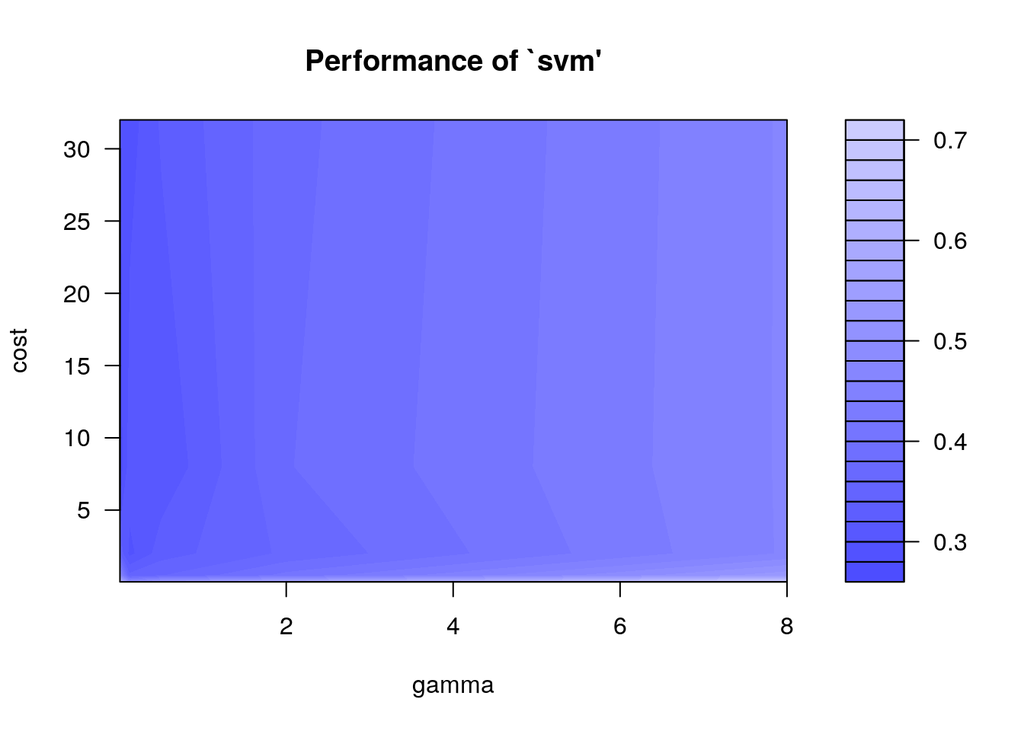

```r
plot(svm1t)
```